Machine Learning Study Groups

Klaudia Łubian, 12/11/2019

# Uczenie głębokie i przetwarzanie obrazu

Rozdział 5 *Deep Learning with Python* by Francois Chollet

## Konwolucyjne sieci neuronowe (*Convolutional neural networks*) w Python

Wprowadzenie do sieci typu **convnets**, najpopularniejszych wśród modeli przetwarzania obrazu. Czemu?

### 1. Sieci typu Convnets vs. Dense - różnice

Podstawową różnicą między warstwą gęstych połączeń a siecią konwolucyjną jest to, że **warstwy gęste uczą się cech globalnych w swoich wejściowych przestrzeniach a warstwy konwolucyjne uczą się lokalnych wzorców.**

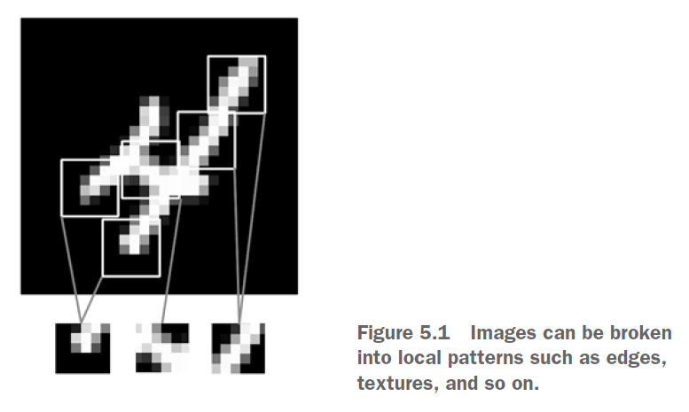

Dzięki tej kluczowej charakterystyce sieci konwolucyjne mają dwie ciekawe właściwości:

- charakteryzują się **dużą wydajnością podczas przetwarzania obrazów** - mogą skutecznie tworzyć uogólnienia po przetworzeniu mniejszego zbioru testowego,
- mogą uczyć się **przestrzennej hierarchii wzorców** - pierwsza warstwa sieci konwolucyjnej uczy się małych lokalnych wzorców, druga - większych struktur składających się z elementów rozpoznanych przez pierwszą warstwę itd.

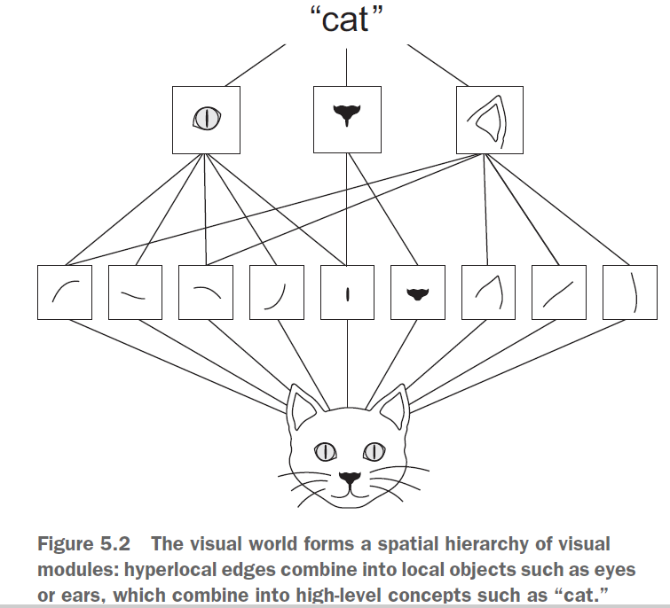

### 2. Zarys podstawowego modelu

Podstawowa sieć konwolucyjna w Keras (Python):

- jest stosem warstw **Conv2D** oraz **MaxPooling2D**,
- ostatni tensor wyjściowy jest przekazany do klasyfikatora w postaci sieci gęstej - do stosu warstw **Dense**.

```
model = models.Sequential()
model.add(layers.Conv2D(...)
model.add(layers.MaxPooling2D(...)
model.add(layers.Conv2D(...)
model.add(layers.MaxPooling2D(...)
model.add(layers.Conv2D(...)

model.add(layers.Flatten())
model.add(layers.Dense(...)
model.add(layers.Dense(...)
```

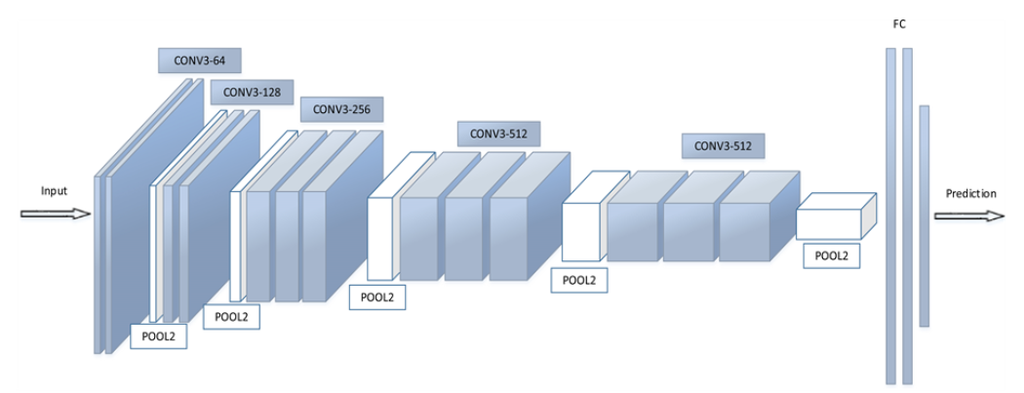

### 3. Tensor wejściowy: mapa cech

Sieci konwolucyjne (warstwa **Conv2D**) przyjmują trójwymiarowe tensory wejściowe zwane **mapami cech** (*feature maps*), które mają:

- dwie przestrzenne osie definiujące wysokość i szerokość,
- trzecią osią jest oś głębi, nazywana również osią kanałów.

*Przykład*

W przykładzie zbioru MNIST, pierwsza warstwa konwolucyjna (Conv2D) przyjmuje mapę cech o rozmiarze (28, 28, 1): 28x28 pixels w skali szarości (głębokość=1)

```
model = models.Sequential()
model.add(layers.Conv2D(..., activation='relu', input_shape=(28, 28, 1)))
```

### 4. Wyjściowa mapa cech

Sieci konwolucyjne dokonują ekstrakcji łat z cech wejściowych i przeprowadzają tę samą operację (np. relu) na wszystkich łatach w celu utworzenia **wyjściowej mapy cech** (*output feature map*). Mapa ta jest nadal trójwymiarowym tensorem:

- ma szerokość i wysokość,
- wyjściowa wartość głębi jest parametrem warstwy, kanały osi głębi stają się **filtrami**. Filtry kodują określone cechy danych wejściowych: np. pojedynczy filtr może kodować „obecność twarzy w obrazie wejściowym”.

*Przykład*

W przykładzie zbioru MNIST, pierwsza warstwa konwolucyjna (Conv2D):

- przyjmuje mapę cech o rozmiarze (28, 28, 1),
- zwraca na wyjściu mapę cech o rozmiarze (26, 26, 32).

Oznacza to, że:

- na danych wejściowych obliczane są wartości 32 filtrów,
- każdy z tych 32 filtrów zawiera siatkę 26x26 wartości będącą **mapą odpowiedzi filtra na dane wejściowe** (*response map*).

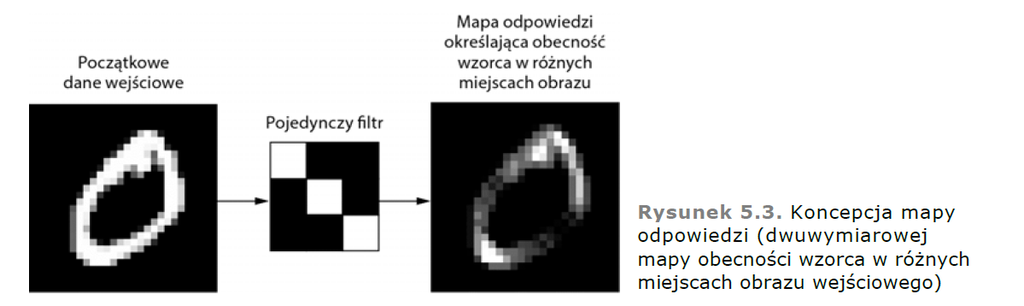

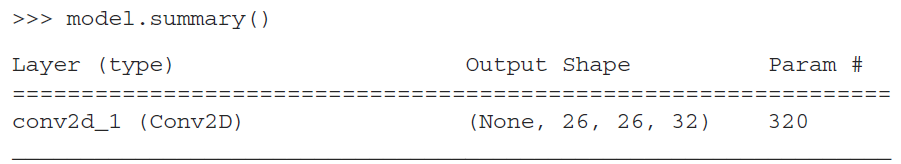

### 5. Parametry warstwy *Conv2D*

*Przykład*

Pełna specyfikacja pierwszej warstwy konwolucyjnej dla zbioru MNIST w Keras:

```
model = models.Sequential()
model.add(layers.Conv2D(32, (3, 3), activation='relu', input_shape=(28, 28, 1)))
```

*Conv2D(32, (3, 3)* --> *Conv2D(głębia wyjścia, (wysokość okna, szerokość okna))*

Konwolucje są definiowane przez dwa główne parametry:

- Rozmiar łat wyciągniętych z danych wejściowych — zazwyczaj 3 × 3 or 5 × 5.
- Głębia wyjściowej mapy cech — liczba filtrów obliczona przez konwolucję.

### 6. Działanie warstwy *Conv2D*

1. Konwolucja polega na przesuwania okien o wymiarach 3x3 po trójwymiarowej wejściowej mapie cech (input_shape=(28, 28, 1)).
2. Okno jest zatrzymywane w każdym miejscu, w którym da się je umieścić, i dokonywana jest ekstrakcja 3D łaty otaczających je cech (łata ta ma kształt (wysokość_okna, szerokość_okna, głębia_wejścia)) - w naszym przykładzie (3, 3, 1).
3. Każda taka 3D łata jest następnie przekształcana (poprzez iloczyn tensorowy z jedną wyuczoną macierzą wag, określaną mianem **jądra konwolucji**) w celu uzyskania jednowymiarowego wektora o kształcie (głębia_wyjścia = 32).
4. Wszystkie te wektory są następnie przestrzennie przebudowywane w celu utworzenia 3D mapy wyjściowej o kształcie (wysokość, szerokość, głębia_wyjścia). To jest wspomniana **mapa odpowiedzi filtra na dane wejściowe** (*response map*), w MNIST o rozmiarze (26, 26, 32). Oznacza to, że dolny prawy róg mapy wyjściowej zawiera informacje o prawym dolnym rogu mapy wejściowej.

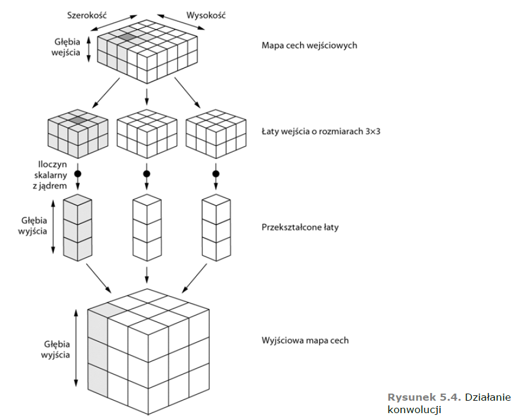

Szerokość i wysokość obiektu wyjściowego może różnić się od szerokości i wysokości obiektu wejściowego. W przykładzie zbioru MNIST, pierwsza warstwa konwolucyjna (Conv2D):

- przyjmuje mapę cech o rozmiarze (28, 28, 1): szerokość i wysokość: 28
- zwraca na wyjściu mapę cech o rozmiarze (26, 26, 32): szerokość i wysokość: 26, ten rozmiar **nie** został przez nas zdefiniowany:

  ```
  model = models.Sequential()
  model.add(layers.Conv2D(32, (3, 3), activation='relu', input_shape=(28, 28, 1)))
  ```

Może to wynikać z dwóch czynników:

- **efektów granicznych**, którym można przeciwdziałać, dopełniając mapę cech wejściowych;
- użycia **kroków**.

### 7. Efekty graniczne i dopełnianie

Załóżmy, że pracujemy z przykładową mapą cech o wymiarach 5x5 (mapa ta składa się z 25 pól). Zawiera ona tylko 9 pól, na których można ustawić środek okna o wymiarach 3x3 tworzącego siatkę 3x3 pola.

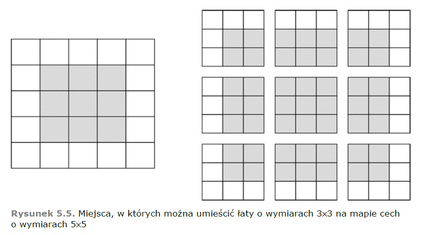

Gdybyśmy chcieli uzyskać wyjściową mapę cech o takich samych wymiarach jak mapa wejściowa, to musielibyśmy skorzystać z techniki **dopełniania**. Polega ona na dodawaniu odpowiedniej liczby wierszy i kolumn po każdej stronie wejściowej mapy cech tak, aby można było zmieścić na tej mapie odpowiednią liczbę razy środek okna konwolucji.

```
model = models.Sequential()
model.add(layers.Conv2D(32, (3, 3), activation='relu', input_shape=(28, 28, 1), padding = "same"))
```

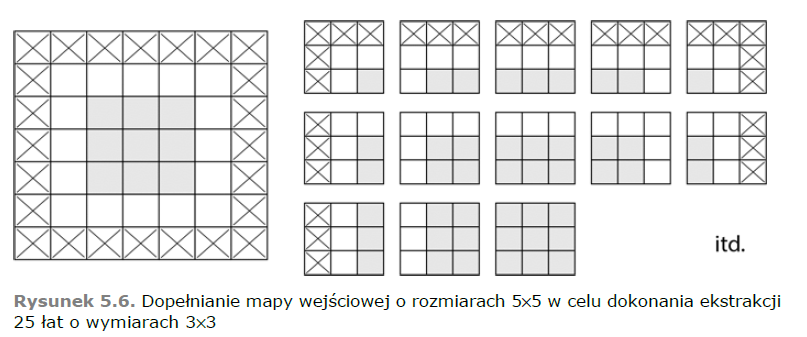

### 8. Kroki procesu konwolucji

**Krok** (*stride*) - odległość między dwoma kolejnymi oknami w procesie konwolucji. Domyślnie przyjmuje on wartość 1, ale można przypisać mu większą wartość, co doprowadzi do uzyskania tzw. **konwolucji kroczących**.

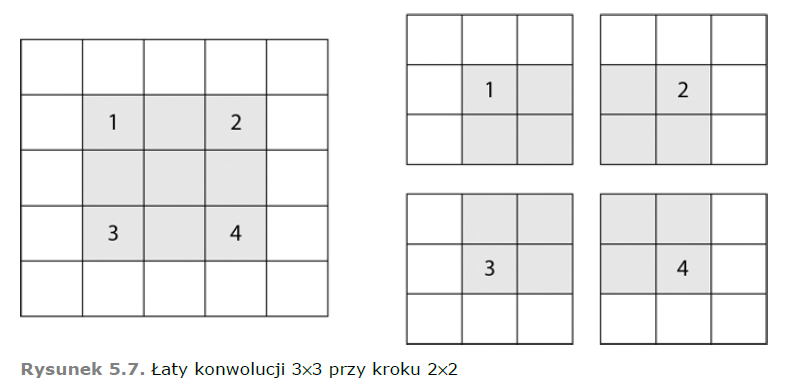

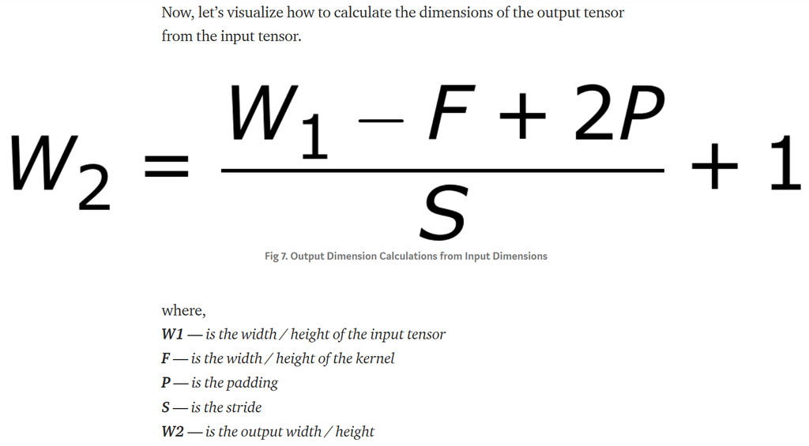

source: https://towardsdatascience.com/convolutional-neural-network-17fb77e76c05

W przykładzie zbioru MNIST, pierwsza warstwa konwolucyjna (Conv2D):

- przyjmuje mapę cech o rozmiarze (28, 28, 1): szerokość i wysokość: 28
- zwraca na wyjściu mapę cech o rozmiarze (26, 26, 32): szerokość i wysokość: 26, ten rozmiar **nie** został przez nas zdefiniowany, ale możemy go obliczyć:

W2 = ((28 - 3 + 2x0)/1) + 1

W2 = 26

### 9. Operacja *max-pooling*

Podstawowa konwolucyjna sieć neuronowa w Keras jest stosem warstw **Conv2D** oraz **MaxPooling2D**:

```
model = models.Sequential()
model.add(layers.Conv2D(...)
model.add(layers.MaxPooling2D(...)
model.add(layers.Conv2D(...)
model.add(layers.MaxPooling2D(...)
model.add(layers.Conv2D(...)
```

Operacja **MaxPooling2D** ma w sposób agresywny zmniejszać rozdzielczość map cech aby:

- zredukować liczby przetwarzanych współczynników mapy cech,
- kolejne warstwy konwolucji analizowały coraz większe okna, przez które widać coraz większy obszar obrazu wejściowego).

*Przykład*

Operacja max-pooling przeprowadzona przy użyciu okien o wymiarach 2x2 przy kroku równym 2 (ma to na celu dwukrotne zredukowanie mapy cech).

```
model.add(layers.MaxPooling2D((2, 2)))
```

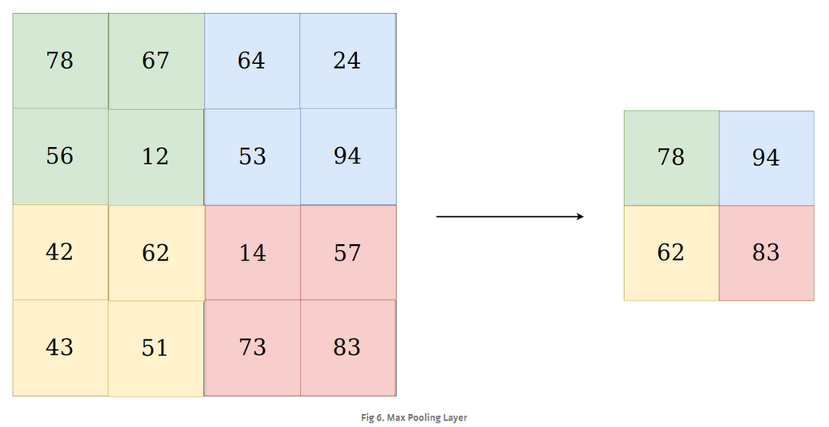

### 10. Konwolucyjna sieć neuronowa dla zbioru MNIST

```
from keras import layers
from keras import models

model = models.Sequential()
model.add(layers.Conv2D(32, (3, 3), activation='relu', input_shape=(28, 28, 1)))
model.add(layers.MaxPooling2D((2, 2)))
model.add(layers.Conv2D(64, (3, 3), activation='relu'))
model.add(layers.MaxPooling2D((2, 2)))
model.add(layers.Conv2D(64, (3, 3), activation='relu'))

model.add(layers.Flatten())
model.add(layers.Dense(64, activation='relu'))
model.add(layers.Dense(10, activation='softmax'))
```

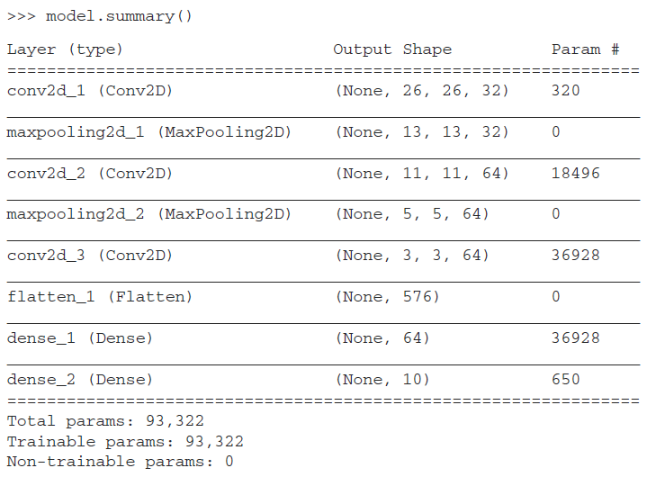